# Centers of Population by Race/Ethnicity

Harrison DeFord (hdeford1 at umbc dot edu)

October 10, 2024

Every decennial census, the U.S. Census Bureau releases an updated version of the [Mean Center of Population](https://www.census.gov/geographies/reference-files/time-series/geo/centers-population.html), which can be interpreted as the “center of gravity” of the U.S. population.

# Libraries

First, we’ll load required libraries:

```r
library(tidyverse)
library(tidycensus)
library(tigris)
library(sf)
library(tmap)
library(tmaptools)
library(showtext)
library(furrr)
library(data.table)
library(dtplyr)
options(tigris_use_cache = TRUE)
options(scipen = 999)
extrafont::loadfonts(device = "win", quiet = T)

rm(list = ls())
yr = 2010
```

# Parallelization

Since we’re computing at the block level (11 million blocks) across 7 groups, we’ll have a dataframe with over 70 million rows at its highest. I actually had to upgrade to 32GB of memory to run this analysis: we’re going to create a `{furrr}` multisession using all but one of our CPU threads. In my case, that’s 11 threads.

```r
fips_list <- unique(fips_codes$state)[1:51]
num_cores <- availableCores()-1
plan(multisession, workers = num_cores)
```

Now that our multisession is planned, we can start gathering our census data. The `{tidycensus}` package provides a fantastic interface to the USCB API, but at the block level we can only collect data one state at a time. However, by using `future_map()` to iterate over our list of state FIPS codes (`fips_list`) created earlier, we can gather 11 states worth of data simultaneously until we’ve obtained population counts for all 50 states, then `reduce()` them into one very long dataframe.

# Census Data Collection

Note that we gather tabular data (`b`) and spatial data (`c`) separately, to be stored in two different files on our machine. This code block takes my machine 20-30 minutes to run – luckily, once you’ve run it once, you shouldn’t have to run it again thanks to the power of `fwrite()`!

```r
## Not run:

if (yr < 2020){
  pop_vars <- c(white = "P005003",
                black = "P005004",
                aian = "P005005",
                asian = "P005006",
                hipi = "P005007",
                other = "P005008",
                two_p = "P005009",
                hisp = "P005010")
} else {
  pop_vars <- c(white = "P2_005N",
                black = "P2_006N",
                aian = "P2_007N",
                asian = "P2_008N",
                hipi = "P2_009N",
                other = "P2_010N",
                two_p = "P2_011N",
                hisp = "P2_002N")
}

b <- reduce(future_map(fips_list, function(x){
  get_decennial(geography = "block",
                           variables = pop_vars,
                           year = yr,
                           state = x,
                           output = "tidy",
                           geometry = FALSE)}, .progress = TRUE), rbind)

c <- reduce(future_map(fips_list, function(x){blocks(state = x, year = yr) %>%
     st_drop_geometry() %>%
     mutate(across(.cols = starts_with("INTPTLON"), .fns = as.numeric, .names = "lon")) %>%
     mutate(across(.cols = starts_with("INTPTLAT"), .fns = as.numeric, .names = "lat")) %>%
     select(c(5,last_col(offset = 1), last_col()))}, .progress = TRUE), rbind)

future:::ClusterRegistry("stop")

fwrite(as.data.table(b), paste0("../data/pop_data_", yr, ".csv"))
fwrite(as.data.table(c), paste0("../data/latlon_", yr, ".csv"))

## End(Not run)
```

# Calculations

Now, we need to join our tables in order to weight the internal point of each block with its respective population. Note the usage of `{dtplyr}` here: I wanted to keep writing in tidyverse syntax while gaining the performance of `{data.table}`. What a fantastic package!

The formula used is derived from [this document](https://www2.census.gov/geo/pdfs/reference/cenpop2020/COP2020_documentation.pdf). Since block-level population centers aren’t available through `{tigris}`, we will use the “internal point” latitude and longitude. The internal point of a geography is often the centroid: if a geography is shaped such that the centroid would fall outside its boundary, the internal point is placed as close to the internal centroid of the geography as possible, preferably on land.

```r
b <- lazy_dt(fread(paste0("../data/pop_data_", yr, ".csv")))
c <- lazy_dt(fread(paste0("../data/latlon_", yr, ".csv")))
o <- b %>%
  pivot_wider(names_from = variable, values_from = value) %>%
  mutate(other = other + two_p) %>%
  select(-c(two_p)) %>%
  pivot_longer(cols = 3:9, names_to = "variable")

j <- left_join(o, c, by = c("GEOID" = paste0("GEOID", str_sub(yr, 3,4)))) %>%
  mutate(elat = value * lat,
         elon = value * lon * cos(lat * (pi/180)),
         denom = value*cos(lat * (pi/180)))


g <- j %>%
  group_by(variable) %>%
  summarize(tlat = sum(elat, na.rm = TRUE)/sum(value, na.rm = TRUE),
            tlon = sum(elon, na.rm = TRUE)/sum(denom, na.rm = TRUE),
            pop = sum(value))

g <- as.data.table(g)

s <- g %>%
  st_as_sf(coords = c("tlon","tlat")) %>% st_set_crs(4326) %>% st_transform(6350)

cc <- as.data.table(j) %>%
  summarize(tlat = sum(elat, na.rm = TRUE)/sum(value, na.rm = TRUE),
            tlon = sum(elon, na.rm = TRUE)/sum(denom, na.rm = TRUE),
            pop = sum(value)) %>%
  st_as_sf(coords = c("tlon", "tlat")) %>% st_set_crs(4326) %>% st_transform(6350)

lso <- vector(mode = 'list', length = nrow(s))

for (row in 1:nrow(s)){
  cs <- data.frame(st_coordinates(cc)[1], st_coordinates(cc)[2]) %>%
  rename(p_x = 1,
         p_y = 2) %>%
  mutate(seq = 1)
  cs <- cbind(g[,c(1,4)],cs)

  ss <- s[row,] %>%
    rowwise() %>%
    mutate(p_x = unlist(geometry)[1],
           p_y = unlist(geometry)[2]) %>%
    mutate(seq = 2) %>%
    st_drop_geometry() %>%
    ungroup()

  ap <- rbind(ss,cs[row,]) %>%
    arrange(variable, seq)

  m <- as.matrix(ap[order(ap$seq),
                    c("p_x","p_y")])

  ls <- st_linestring(m) %>%
    st_sfc() %>%
    st_sf() %>%
    mutate(variable = ap$variable[1],
           pop = ap$pop[1]) %>%
    bind_cols()

  lso <- lso %>% bind_rows(ls)
}

lsp <- lso %>% st_set_crs(6350)
```

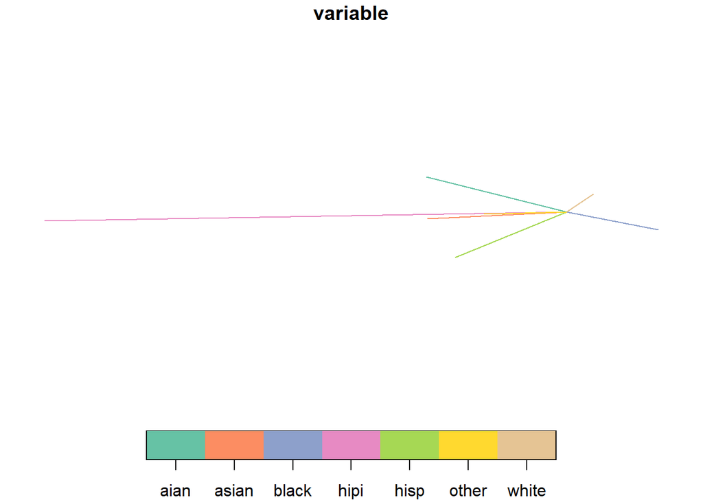

```r
s <- s %>% mutate(pop_pct = pop/sum(pop),
                  log_pct = abs(log(pop_pct)),
                  normalized_log_pct = 0.1 + (log_pct - max(log_pct)) / (min(log_pct) - max(log_pct)) * (0.7 - 0.1))

plot(lsp["variable"])
```

# Plotting

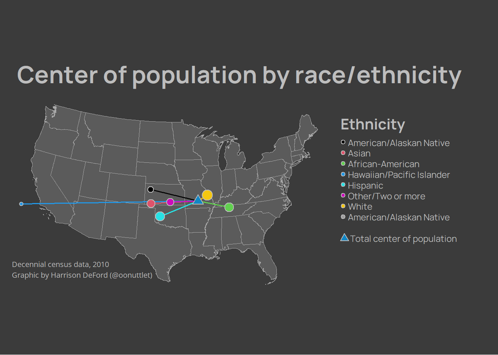

```r
ilh <- palette(c(rgb(114,153,67, maxColorValue = 255),
                 rgb(148,79,161, maxColorValue = 255),
                 rgb(76,196,144, maxColorValue = 255),
                 rgb(185,74,115, maxColorValue = 255),
                 rgb(193,158,60, maxColorValue = 255),
                 rgb(104,123,210, maxColorValue = 255),
                 rgb(185,85,61, maxColorValue = 255)))

plot_fips <- unique(fips_codes$state_code)[1:51]
plot_fips <- plot_fips[!plot_fips %in% c("02", "15", "72", "78")]

us <- states(cb = TRUE, year = yr) %>% filter(if (yr == 2010) STATE %in% plot_fips else
                                                 STATEFP %in% plot_fips) %>%
  st_transform(6350) #weird artifact in tigris means that column names don't match

t <- tm_shape(us, bbox = bb(us, ext = 1.1))+
  tm_polygons(border.col = "#aaaaaa", lwd = 0.75, col = "#5b5b5b")+
  tm_shape(lsp)+
  tm_lines(col = "variable", palette = ilh, legend.col.show = FALSE, lwd = 1.5, legend.lwd.show = FALSE)+
  tm_shape(s)+
  tm_symbols(col = "variable", title.col = "Race/Ethnicity", size = "normalized_log_pct", border.col = "#bdbdbd", palette = ilh, border.lwd = 1, legend.col.show = FALSE, legend.size.show = FALSE)+
  tm_shape(cc)+
  tm_dots(col = "#1286c4", shape = 24, title = "Total center of population", size = 0.6, legend.show = FALSE, border.lwd = 1, border.col = "#bdbdbd")+
  tm_add_legend(type = "symbol",
    labels = c("American/Alaskan Native", "Asian", "African-American", "Hawaiian/Pacific Islander", "Hispanic", "Other/Two or more", "White"),
    col = ilh,
    border.col = "#bdbdbd",
    title = "Ethnicity",
    size = 0.4)+
  tm_add_legend(type = "symbol",
                shape = 24,
                col = "#1286c4",
                size = 0.6,
                border.col = "#bdbdbd",
                labels = "Total center of population")+
  tm_layout(main.title = "Center of population by race/ethnicity",
            main.title.fontfamily = "Manrope",
            main.title.fontface = 2,
            main.title.size = 2,
            bg.color = "#3b3b3b",
            legend.outside = TRUE,
            legend.text.color = "#bdbdbd",
            legend.text.fontfamily = "Manrope",
            legend.title.color = "#bdbdbd",
            legend.title.fontface = 2,
            legend.title.size = 1.5,
            legend.title.fontfamily = "Manrope",
            legend.text.size = 0.75,
            legend.position = c(0,0.25),
            outer.bg.color = "#3b3b3b",
            frame = FALSE,
            main.title.color = "#bdbdbd")+
  tm_credits(paste0("Decennial census data, ", yr, "\nGraphic by Harrison DeFord (@oonuttlet)"),
             position = c(0,0.08),
             col = "#bdbdbd",
             fontfamily = "Open Sans",
             size = 0.62)

t
```

```r
tmap_save(t, paste0("../bin/center_of_pop_natl_",yr,"_intpt.png"), dpi = 1200)
```